## How (and why) to work as an open scientist in the 21st century

```
Stephen J Eglen                  Cambridge Computational Biology Institute
https://sje30.github.io          University of Cambridge
sje30@cam.ac.uk                  @StephenEglen
```

Slides: <http://bit.ly/eglen-todos> (CC-BY license)

#### Declarations

1. Affiliate editor of *bioRxiv*
2. Senior editor of *Scientific Data*

#### Acknowledgements

Laurent Gatto, Corina Logan, Daniel Nüst, Ben Marwick

## About me

My research and how I got into open science.

## What is open science

- My definition of open science: a way to approach research which
  promotes sharing of (all / most) research artifacts.

- From this, open access (OA) to research papers is normally assumed.  But
  we all make mistakes...

## Ooh, a Nature publication?

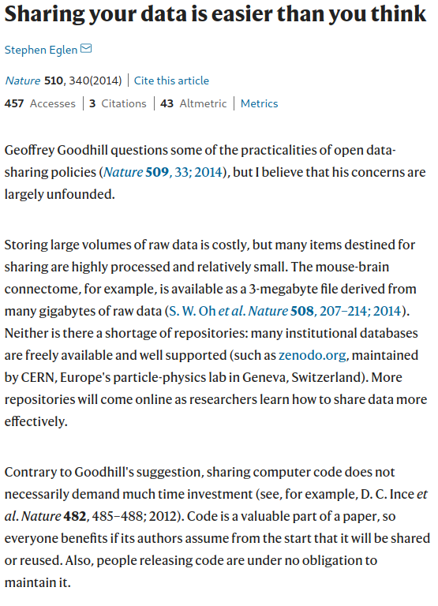

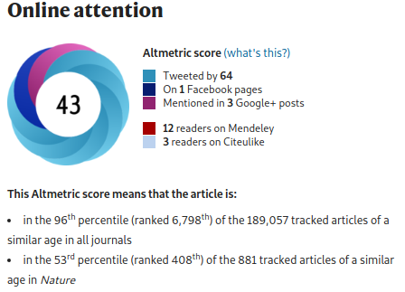

#### Twitter can be a tough place ...

[figure not shown]

from which I learnt altmetrics can
mislead and that I should **preprint**.

## The reproducibility crisis

Many key findings in publications are either not independently
verified, or fail verification when it is attempted (Baker, 2016).
<a href="http://dx.doi.org/10.1038/533452a">10.1038/533452a</a>

Duke oncogenomics scandal.  Awesome detective work by Keith Baggerley
and Kevin Coombes.
<https://www.youtube.com/watch?v=7gYIs7uYbMo>

Disclaimer: do I mean "reproducibility" or "replicability"?
(Barba 2018) <https://arxiv.org/pdf/1802.03311.pdf>

## Reproducibility crisis

Crisis?  What crisis?  Science is getting better, right?

"Negative results are disappearing from most disciplines and
countries" [(Fanelli, 2012)](http://dx.doi.org/10.1007/s11192-011-0494-7).  Study of ~4600
papers:

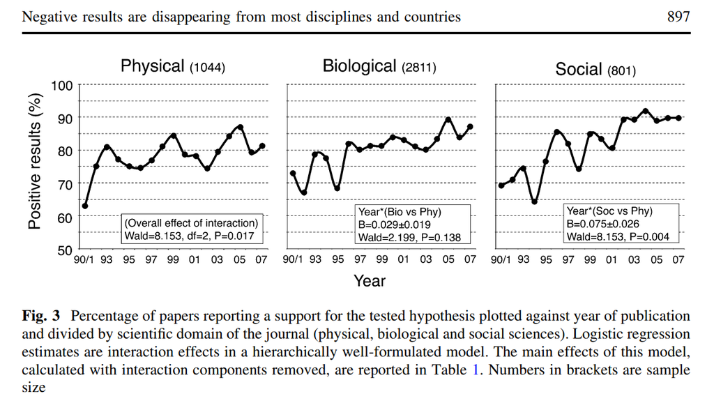

# WHY

### Science as an inverse problem

[figure not shown]

## Why share your work?

> An article about computational science in a scientific publication
> is not the scholarship itself, it is merely advertising of the
> scholarship. The actual scholarship is the complete software
> development environment and the complete set of instructions which
> generated the figures.

[Buckheit & Donoho (1995)](https://link.springer.com/chapter/10.1007/978-1-4612-2544-7_5)

> The problem is that most modern science is so complicated, and most
> journal articles so brief, it’s impossible for the article to
> include details of many important methods and decisions made by the
> researcher

[Marwick (2015)](https://theconversation.com/how-computers-broke-science-and-what-we-can-do-to-fix-it-49938)

This often plays into the moral argument for sharing your work
(taxpayers money etc), but doesn't apply (e.g. Humanities).

## Moral or selfish approach to sharing?

[figure not shown]

10.1186/s13059-015-0850-7

## Selfish reasons to share

Why not align what is good for science with what is good for
scientists?

1. Funding mandates (REF + enforcement from Wellcome Trust)
2. Credit through data papers
3. Fixes data bugs / errors in analysis
4. Prevent data loss [(Vines et al 2014)](http://www.ncbi.nlm.nih.gov/pubmed/24361065). e.g. students have a habit of leaving...
5. Your future self is probably one of the main beneficiaries of
   sharing.
6. *Now* is a very good time to be an open scientist.
7. Leads to further collaborations
8. Reviewers can do more work...

# HOW

## Rule 1: Data should be shared

Given the cost of generating data, I think data relating to a
publication should be shared along with the paper.

Funders (and increasingly many, but not all, journals) agree.

Exceptions: human / clinical datasets where GDPR relevant.

## Where to store your research data?

Ask your local librarian experts about the possibilities available to
you:

- Institutional repositories (local support but what if you move)

- National repositories (probably more flexible)

- Subject-specific repositories:
  [https://journals.plos.org/plosone/s/data-availability#loc-recommended-repositories](PLOS recommendations).

- The big general repos: [Zenodo](www.zenodo.org) [figshare](www.figshare.org)

## Learn about licensing

- How can you licence your work so that you can share it and yet protect
it?

- Again, best to seek local advice from librarians.

- [https://choosealicense.com/non-software/](https://choosealicense.com/non-software/)

- My preferences: MIT (for code) and CC BY (for data etc).

## Get a good mentor

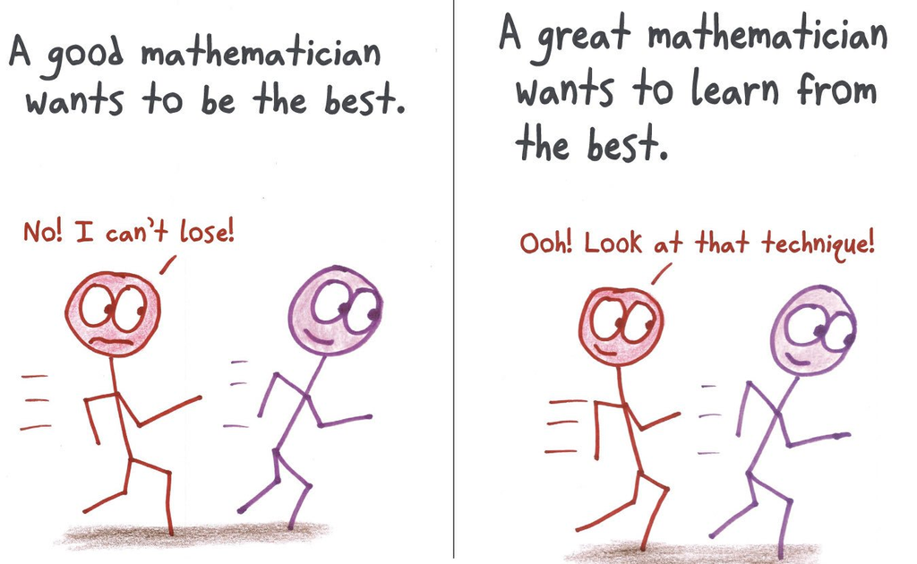

Science is hard enough without having to be competitive.

Having a local group to talk about these issues is great.  I have
learnt much about open science from postdocs (often online).

Ben Orlin, Math with Bad Drawings

## Format-free submissions

[figure not shown]

[Source](https://twitter.com/StephenEglen/status/848195917148717057)

[Don't format manuscripts: Brischoux &  Legagneux](http://www.the-scientist.com/?articles.view/articleNo/27482/title/Don-t-Format-Manuscripts/)

## Coding

- Coding is a 21st century skill that everyone needs to know.

- Start by moving away from Excel to R for statistical analysis and
  drawing figures.

- Good Places to learn coding and related skills:  [Software
Carpentry](https://software-carpentry.org) [Data
carpentry](https://datacarpentry.org) [Library
Carpentry](https://librarycarpentry.org/).

#### Bonus - Reproducible figures

```r
library(ggplot2); library(patchwork) # github.com/thomasp85/patchwork
p1 = ggplot(mtcars) + geom_point(aes(mpg, disp)) + labs(tag="A")
p2 = ggplot(mtcars) +
  geom_boxplot(aes(gear, disp, group = gear)) + labs(tag="B")
p3 = ggplot(mtcars) + geom_smooth(aes(disp, qsec)) + labs(tag="C")
p4 = ggplot(mtcars) + geom_bar(aes(carb)) + labs(tag="D")
((p1 | p2 | p3) /  p4 ) + theme_bw()
```

[figure not shown]

## Registered reports

- A positive approach to reducing p-hacking and HARKing (Hypothesising
  After Results Known). [Cerebral
  Cortex 2013](https://www.elsevier.com/editors-update/story/peer-review/spliting-the-review-process-into-two-stages)

- Peer review process split into two steps.

- **Step 1** methods and proposed analyses are pre-registered and
  reviewed.

- If peer reviews are favourable, authors get "accept in princple" for
  their paper *regardless* of results.

- **Step 2** after results collected, paper is written.

- This commits authors to think about analysis before experiment

- Extra analyses can be reported as "incidental findings".

- Analysis so far suggests an increase in the reporting of null
results, cf earlier slide. <https://www.nature.com/articles/d41586-018-07118-1>

## Preprints

[figure not shown]

## Why preprint?

Advantages (https://www.plos.org/why-preprint):

1. Rapid dissemination of results
2. Establish priority
3. Increased attention/citations
4. Career advancement
5. Community
6. Unlimited / timely updates

Also: potential for early feedback, error reduction, improved
citations, editors might fish for papers.

Preprints are valid research outputs for REF2021 [Naomi
Penfold](https://asapbio.org/preprints-valid-for-ref2021).

## When to submit a preprint?

Estimates from <https://nikokriegeskorte.org/2016/03/13/the-selfish-scientists-guide-to-preprint-posting/>

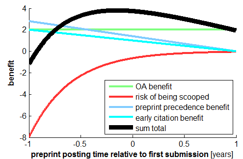

Selfish approach, adopted by many: submit preprint at time
of submissions.

### Evaluate journal subscription model

Think about which journals you support, by sending papers and
reviewing.

Support OA journals as authors and reviewers.  (Ever asked a journal
for permission to republish one of your own figures?)

Check out status of journal via Sherpa/Romeo service.

## What can your institutions & funders do?

- sign up to DORA (Declaration of Research Assessment)
(Wellcome Trust have solved this problem).  Signing is easy, enforcing
is hard.

- Give ECR a voice within institutions.

- Recognise all research artefacts, not just papers, as valuable
  outputs.

- Give academics more ownership of funds.  "Do you really want to
   spend 5K on an APC, versus other uses in your lab?"

- Routes to OA need to be generate less admin for librarians /
   funders, not more.  Green OA achieves that.

- Support diamond OA initiatives led by academics and academic
   societies.

## Summary

* Find the selfish reasons to make your research reproducible.

* Adopt good practices to help you on your way.

* Writing code and analysing data in groups can be very motivating.

* Use new tech if you want, but old tech works too.

## Conclusions

- Technical challenges << Societal challenges

- You are the future and so is open science!

- Its a journey, we learn these techniques over time.

#### Extra resources

1. [Turing Way handbook; "a lightly opinionated guide to reproducible
   data
   science"](https://the-turing-way.netlify.com/introduction/introduction)

2. [Towards standard practices for sharing code in
   neuroscience](https://www.nature.com/articles/nn.4550)

3. [Ten simple rules for taking advantage of git and github](https://doi.org/10.1371/journal.pcbi.1004947)